# Unsupervised Learning: Trade & Ahead

### Silhouette Scores

```
For n_clusters = 2, the silhouette score is 0.45335782729503565)
For n_clusters = 3, the silhouette score is 0.40374060030338865)
For n_clusters = 4, the silhouette score is 0.4246430808437099)
For n_clusters = 5, the silhouette score is 0.4381539778147092)
For n_clusters = 6, the silhouette score is 0.40869599703024256)
For n_clusters = 7, the silhouette score is 0.1207450219233897)
For n_clusters = 8, the silhouette score is 0.3693991650696542)
For n_clusters = 9, the silhouette score is 0.35185096182499204)
For n_clusters = 10, the silhouette score is 0.32950073703610283)
For n_clusters = 11, the silhouette score is 0.1486586842527321)
For n_clusters = 12, the silhouette score is 0.15784241071085106)
For n_clusters = 13, the silhouette score is 0.15646997458716602)
For n_clusters = 14, the silhouette score is 0.16253506827999134)
For n_clusters = 15, the silhouette score is 0.13292390538523347)
```

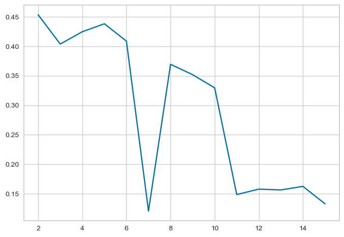

```python
sil_score = []
cluster_list = range(2,16)

for n_clusters in cluster_list:
    clusterer = KMeans(n_clusters=n_clusters, random_state=1)
    preds = clusterer.fit_predict((subset_scaled_df))
    score = silhouette_score(k_means_df, preds)
    sil_score.append(score)
    print("For n_clusters = {}, the silhouette score is {})".format(n_clusters, score))

plt.plot(cluster_list, sil_score)
plt.show()
```

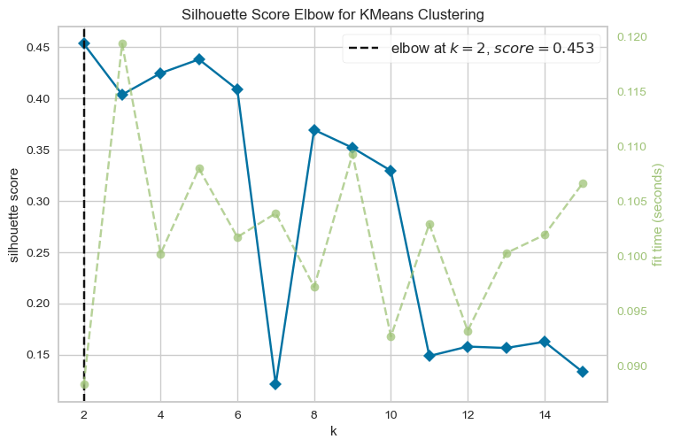

```python
model = KMeans(random_state=1)
visualizer = KElbowVisualizer(model, k=(2,16), metric='silhouette', timings=True)
visualizer.fit(k_means_df)
visualizer.show()
```

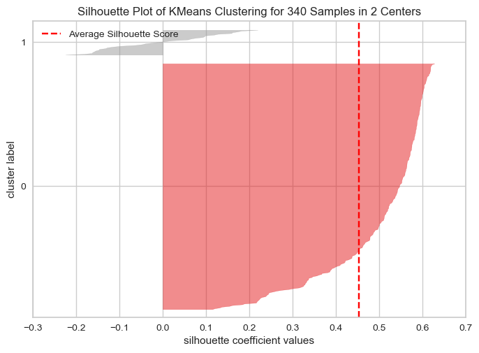

```python
# Finding optimal number of clusters
visualizer = SilhouetteVisualizer(KMeans(2, random_state=1))
visualizer.fit(k_means_df)
visualizer.show()
```

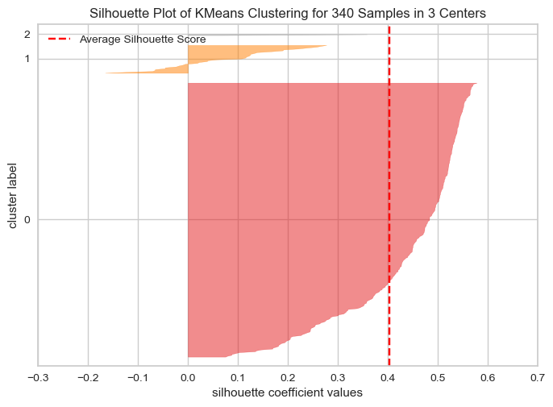

```python
# Finding optimal number of clusters
visualizer = SilhouetteVisualizer(KMeans(3, random_state=1))
visualizer.fit(k_means_df)
visualizer.show()
```

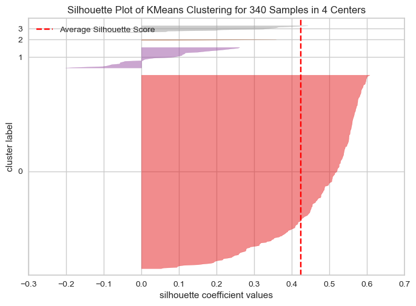

```python
# Finding optimal number of clusters
visualizer = SilhouetteVisualizer(KMeans(4, random_state=1))
visualizer.fit(k_means_df)
visualizer.show()
```

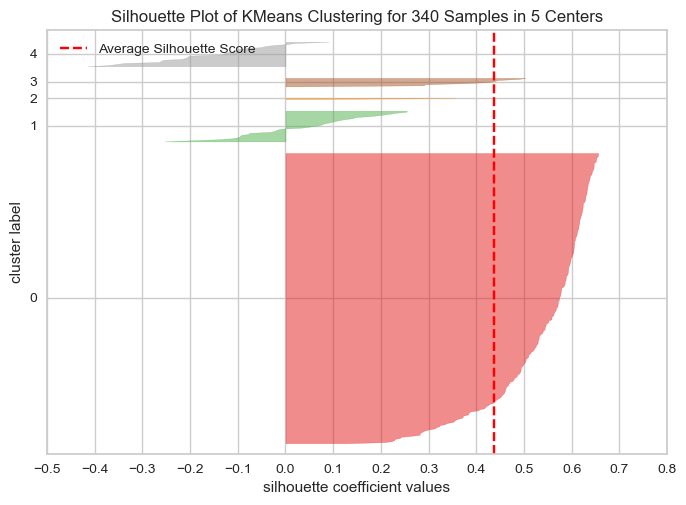

```python
# Finding optimal number of clusters
visualizer = SilhouetteVisualizer(KMeans(5, random_state=1))
visualizer.fit(k_means_df)
visualizer.show()
```

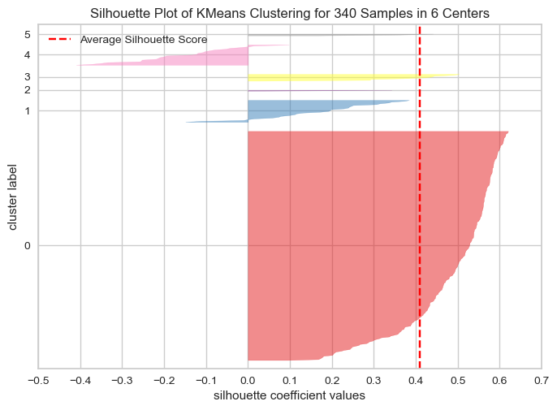

```python
# Finding optimal number of clusters
visualizer = SilhouetteVisualizer(KMeans(6, random_state=1))
visualizer.fit(k_means_df)
visualizer.show()
```

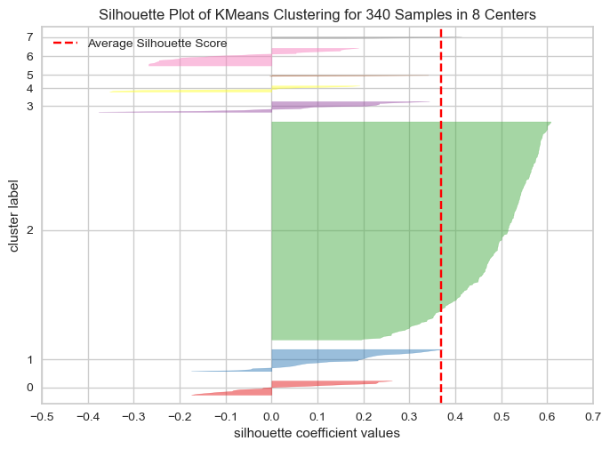

```python
# Finding optimal number of clusters
visualizer = SilhouetteVisualizer(KMeans(8, random_state=1))
visualizer.fit(k_means_df)
visualizer.show()
```

- I have chosen k=4 as the most appropriate number of clusters. The silhouette score is a bit lower but has cleaner clusters overall.

### Creating Final Model

```python
%%time
# Final K-means model
kmeans = KMeans(n_clusters=4, random_state=1)
kmeans.fit(k_means_df)
```

```
CPU times: total: 93.8 ms
Wall time: 83.3 ms
```

```
KMeans(n_clusters=4, random_state=1)
```

```python
# Copy of the original data
df1 = df.copy()

# Adding KMeans cluster labels to the original and scaled dataframes
k_means_df["KM_segments"] = kmeans.labels_
df1["KM_segments"] = kmeans.labels_
```

### Cluster Profiling

```python
cluster_profile = df1.groupby("KM_segments").mean(numeric_only=True)
```

```python
cluster_profile["count_in_each_segment"] = (
    df1.groupby("KM_segments")["Security"].count().values
)
```

```python
cluster_profile.style.highlight_max(color="lightgreen", axis=0)
```

| KM_segments | Current Price | Price Change | Volatility | ROE | Cash Ratio | Net Cash Flow | Net Income | Earnings Per Share | Estimated Shares Outstanding | P/E Ratio | P/B Ratio | count_in_each_segment |
| --- | --- | --- | --- | --- | --- | --- | --- | --- | --- | --- | --- | --- |
| 0 | 84.176635 | 5.702764 | 1.396635 | 33.962712 | 69.972881 | 90456322.033898 | 1517730698.305085 | 3.890390 | 444140390.526542 | 24.645180 | -2.015145 | 295 |
| 1 | 64.263438 | -10.382780 | 2.732033 | 46.812500 | 69.656250 | 205568000.000000 | -2018462218.750000 | -5.177187 | 526311835.891875 | 110.425211 | 1.787692 | 32 |
| 2 | 24.485001 | -13.351992 | 3.482611 | 802.000000 | 51.000000 | -1292500000.000000 | -19106500000.000000 | -41.815000 | 519573983.250000 | 60.748608 | 1.565141 | 2 |
| 3 | 50.517273 | 5.747586 | 1.130399 | 31.090909 | 75.909091 | -1072272727.272727 | 14833090909.090910 | 4.154545 | 4298826628.727273 | 14.803577 | -4.552119 | 11 |

```python
for cl in df1["KM_segments"].unique():
    print("In cluster {}, the following companies are present:".format(cl))
    print(df1[df1["KM_segments"] == cl]["Security"].unique())
    print()
```

```
In cluster 0, the following companies are present:
['American Airlines Group' 'AbbVie' 'Abbott Laboratories'
 'Adobe Systems Inc' 'Archer-Daniels-Midland Co' 'Alliance Data Systems'
 'Ameren Corp' 'American Electric Power' 'AFLAC Inc'
 'American International Group, Inc.' 'Apartment Investment & Mgmt'
 'Assurant Inc' 'Arthur J. Gallagher & Co.' 'Akamai Technologies Inc'
 'Albemarle Corp' 'Alaska Air Group Inc' 'Allstate Corp' 'Allegion'
 'Applied Materials Inc' 'AMETEK Inc' 'Affiliated Managers Group Inc'
 'Amgen Inc' 'Ameriprise Financial' 'American Tower Corp A'
 'AutoNation Inc' 'Anthem Inc.' 'Aon plc' 'Amphenol Corp' 'Arconic Inc'
 'Activision Blizzard' 'AvalonBay Communities, Inc.' 'Broadcom'
 'American Water Works Company Inc' 'American Express Co' 'Boeing Company'
 'Bank of America Corp' 'Baxter International Inc.' 'BB&T Corporation'
 'Bard (C.R.) Inc.' 'BIOGEN IDEC Inc.' 'The Bank of New York Mellon Corp.'
 'Ball Corp' 'Bristol-Myers Squibb' 'Boston Scientific' 'BorgWarner'
 'Boston Properties' 'Caterpillar Inc.' 'Chubb Limited' 'CBRE Group'
 'Crown Castle International Corp.' 'Carnival Corp.' 'Celgene Corp.'
 'CF Industries Holdings Inc' 'Citizens Financial Group' 'Church & Dwight'
 'C. H. Robinson Worldwide' 'Charter Communications' 'CIGNA Corp.'
 'Cincinnati Financial' 'Colgate-Palmolive' 'Comerica Inc.'
 'CME Group Inc.' 'Chipotle Mexican Grill' 'Cummins Inc.' 'CMS Energy'
 'Centene Corporation' 'CenterPoint Energy' 'Capital One Financial'
 'The Cooper Companies' 'CSX Corp.' 'CenturyLink Inc'
 'Cognizant Technology Solutions' 'Citrix Systems' 'CVS Health'
 'Chevron Corp.' 'Dominion Resources' 'Delta Air Lines' 'Du Pont (E.I.)'
 'Deere & Co.' 'Discover Financial Services' 'Quest Diagnostics'
 'Danaher Corp.' 'The Walt Disney Company' 'Discovery Communications-A'
 'Discovery Communications-C' 'Delphi Automotive' 'Digital Realty Trust'
 'Dun & Bradstreet' 'Dover Corp.' 'Dr Pepper Snapple Group' 'Duke Energy'
 'DaVita Inc.' 'eBay Inc.' 'Ecolab Inc.' 'Consolidated Edison'
 'Equifax Inc.' "Edison Int'l" 'Eastman Chemical' 'Equinix'
 'Equity Residential' 'Eversource Energy' 'Essex Property Trust, Inc.'
 'E*Trade' 'Eaton Corporation' 'Entergy Corp.' 'Edwards Lifesciences'
 'Exelon Corp.' "Expeditors Int'l" 'Expedia Inc.' 'Extra Space Storage'
 'Fastenal Co' 'Facebook' 'Fortune Brands Home & Security'
 'FirstEnergy Corp' 'Fidelity National Information Services' 'Fiserv Inc'
 'FLIR Systems' 'Fluor Corp.' 'Flowserve Corporation' 'FMC Corporation'
 'Federal Realty Investment Trust' 'First Solar Inc'
 'Frontier Communications' 'General Dynamics'
 'General Growth Properties Inc.' 'Corning Inc.' 'General Motors'
```

[output cut: 57 more lines]

```
 'Freeport-McMoran Cp & Gld' 'Halliburton Co.' 'Hess Corporation'
 'Hewlett Packard Enterprise' 'Kinder Morgan' 'The Mosaic Company'
 'Marathon Oil Corp.' 'Murphy Oil' 'Noble Energy Inc' 'Netflix Inc.'
 'Newfield Exploration Co' 'National Oilwell Varco Inc.' 'ONEOK'
 'Occidental Petroleum' 'Quanta Services Inc.' 'Range Resources Corp.'
 'Spectra Energy Corp.' 'Southwestern Energy' 'Teradata Corp.'
 'Williams Cos.' 'Wynn Resorts Ltd' 'Cimarex Energy']

In cluster 2, the following companies are present:
['Apache Corporation' 'Chesapeake Energy']

In cluster 3, the following companies are present:
['Citigroup Inc.' 'Ford Motor' 'Gilead Sciences' 'Intel Corp.'
 'JPMorgan Chase & Co.' 'Coca Cola Company' 'Pfizer Inc.' 'AT&T Inc'
 'Verizon Communications' 'Wells Fargo' 'Exxon Mobil Corp.']
```

```python
df1.groupby(["KM_segments", "GICS Sector"])['Security'].count()
```

```
KM_segments  GICS Sector
0            Consumer Discretionary         37
             Consumer Staples               18
             Energy                          5
             Financials                     46
             Health Care                    37
             Industrials                    52
             Information Technology         28
             Materials                      18
             Real Estate                    27
             Telecommunications Services     3
             Utilities                      24
1            Consumer Discretionary          2
             Energy                         22
             Health Care                     1
             Industrials                     1
             Information Technology          4
             Materials                       2
2            Energy                          2
3            Consumer Discretionary          1
             Consumer Staples                1
             Energy                          1
             Financials                      3
             Health Care                     2
             Information Technology          1
             Telecommunications Services     2
Name: Security, dtype: int64
```

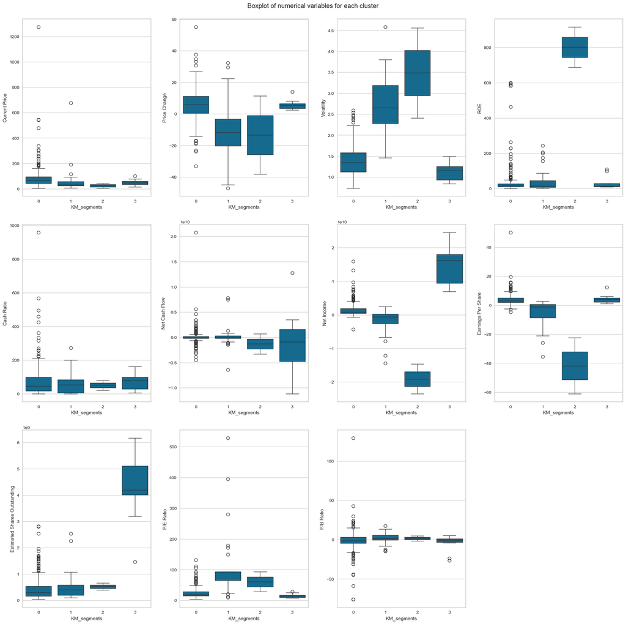

```python
plt.figure(figsize=(20, 20))
plt.suptitle("Boxplot of numerical variables for each cluster")

# selecting numerical columns
num_col = df.select_dtypes(include=np.number).columns.tolist()

for i, variable in enumerate(num_col):
    plt.subplot(3, 4, i + 1)
    sns.boxplot(data=df1, x="KM_segments", y=variable)

plt.tight_layout(pad=2.0)
```

### Insights

- **Cluster 0**:
  - The current price is the highest.
  - The price change is positive in this cluster.
  - Low volatility in this cluster.
  - Relatively low ROE in this cluster.
  - The Net Cash Flow is positive in this cluster.
  - The Net Income is high and positive in this cluster.
  - Earnings per Share are positive in this cluster.
  - This cluster has the highest count (295)
  - **Final Insight:** These are stable, high-price companies with good financials but modest returns on equity. They are likely to appeal to long-term, low-risk investors.
- **Cluster 1**:
  - The current price is relatively high.
  - The price change is negative in this cluster.
  - Relatively high volatility in this cluster.
  - Relatively low ROE in this cluster.
  - The Net Cash Flow is the highest in this cluster.
  - The Net Income is relatively low and negative in this cluster.
  - Earnings per Share are negative in this cluster.
  - This cluster has the highest P/B and P/E ratios.
  - This cluster has a count of 32
  - **Final Insight:** This cluster may include overvalued or underperforming stocks. They are relatively expensive but deliver poor earnings. Possibly driven by speculation or hype, and should be monitored carefully/avoided.
- **Cluster 2**:
  - The current price is relatively low.
  - The price change is most negative in this cluster.
  - Highest volatility in this cluster.
  - Highest ROE in this cluster.
  - The Net Cash Flow is most negative in this cluster.
  - The Net Income is the most negative in this cluster.
  - Earnings per Share are the most negative in this cluster.
  - This cluster has the lowest count (2)
  - **Final Insight:** These are extreme outliers. They combine high ROE with extremely negative financial metrics and high volatility. Could be turnaround candidates or problematic data points. Please look into this further before making any decisions.
- **Cluster 3**:
  - The current price is relatively high.
  - The price change is most positive in this cluster.
  - Low volatility in this cluster.
  - Low ROE in this cluster.
  - The Net Cash Flow is negative in this cluster.
  - The Net Income is the most positive in this cluster.
  - Earnings per Share are highest and most positive in this cluster.
  - This cluster has a count of 11
  - **Final Insight:** This cluster represents strongly profitable companies with excellent earnings per share and the most positive net income, supported by stable prices and positive market sentiment. However, the negative net cash flow raises a red flag; they may be burning through cash despite profitability.

## Hierarchical Clustering

### Cophenetic Correlation

```python
hc_df = subset_scaled_df.copy()
```

```python
# List of distance metrics
distance_metrics = ['euclidean', 'chebyshev', 'mahalanobis', 'cityblock']

# List of linkage methods
linkage_methods = ['single', 'complete', 'average', 'weighted']

high_cophenet_corr = 0
high_dm_lm = [0,0]

for dm in distance_metrics:
    for lm in linkage_methods:
        Z = linkage(hc_df, metric=dm, method=lm)
        c, coph_dists = cophenet(Z, pdist(hc_df))
        print(
            "Cophenetic correlation for {} distance and {} linkage is {}.".format(
                dm.capitalize(), lm, c
            )
        )
        if high_cophenet_corr < c:
            high_cophenet_corr = c
            high_dm_lm[0] = dm
            high_dm_lm[1] = lm

# Printing the combination of distance metric and linkage method with the highest cophenetic correlation
print('*'*100)
print(
    "Highest cophenetic correlation is {}, which is obtained with {} distance and {} linkage.".format(
        high_cophenet_corr, high_dm_lm[0].capitalize(), high_dm_lm[1]
    )
)
```

```
Cophenetic correlation for Euclidean distance and single linkage is 0.9232271494002922.
Cophenetic correlation for Euclidean distance and complete linkage is 0.7873280186580672.
Cophenetic correlation for Euclidean distance and average linkage is 0.9422540609560814.
Cophenetic correlation for Euclidean distance and weighted linkage is 0.8693784298129404.
Cophenetic correlation for Chebyshev distance and single linkage is 0.9062538164750717.
Cophenetic correlation for Chebyshev distance and complete linkage is 0.598891419111242.
Cophenetic correlation for Chebyshev distance and average linkage is 0.9338265528030499.
Cophenetic correlation for Chebyshev distance and weighted linkage is 0.9127355892367.
Cophenetic correlation for Mahalanobis distance and single linkage is 0.9259195530524591.
Cophenetic correlation for Mahalanobis distance and complete linkage is 0.7925307202850002.
Cophenetic correlation for Mahalanobis distance and average linkage is 0.9247324030159736.
Cophenetic correlation for Mahalanobis distance and weighted linkage is 0.8708317490180427.
Cophenetic correlation for Cityblock distance and single linkage is 0.9334186366528574.
Cophenetic correlation for Cityblock distance and complete linkage is 0.7375328863205818.
Cophenetic correlation for Cityblock distance and average linkage is 0.9302145048594667.
Cophenetic correlation for Cityblock distance and weighted linkage is 0.731045513520281.
Highest cophenetic correlation is 0.9422540609560814, which is obtained with Euclidean distance and average linkage.
```

#### Different linkage methods with Euclidean distance

```python
linkage_methods = ['single', 'complete', 'average', 'centroid', 'ward', 'weighted']

high_cophenet_corr = 0
high_dm_lm = [0,0]

for lm in linkage_methods:
    Z = linkage(hc_df, metric='euclidean',method=lm)
    c, coph_dists = cophenet(Z, pdist(hc_df))
    print("Cophenetic correlation for {} linkage is {}.".format(lm, c))
    if high_cophenet_corr < c:
        high_cophenet_corr = c
        high_dm_lm[0] = "euclidean"
        high_dm_lm[1] = lm

# Printing the combination of distance metric and linkage method with the highest cophenetic correlation
print('*'*100)
print(
    "Highest cophenetic correlation is {}, which is obtained with {} linkage.".format(
        high_cophenet_corr, high_dm_lm[1]
    )
)
```

```
Cophenetic correlation for single linkage is 0.9232271494002922.
Cophenetic correlation for complete linkage is 0.7873280186580672.
Cophenetic correlation for average linkage is 0.9422540609560814.
Cophenetic correlation for centroid linkage is 0.9314012446828154.
Cophenetic correlation for ward linkage is 0.7101180299865353.
Cophenetic correlation for weighted linkage is 0.8693784298129404.
Highest cophenetic correlation is 0.9422540609560814, which is obtained with average linkage.
```

#### Checking Dendrograms for different linkage methods with Euclidean distance

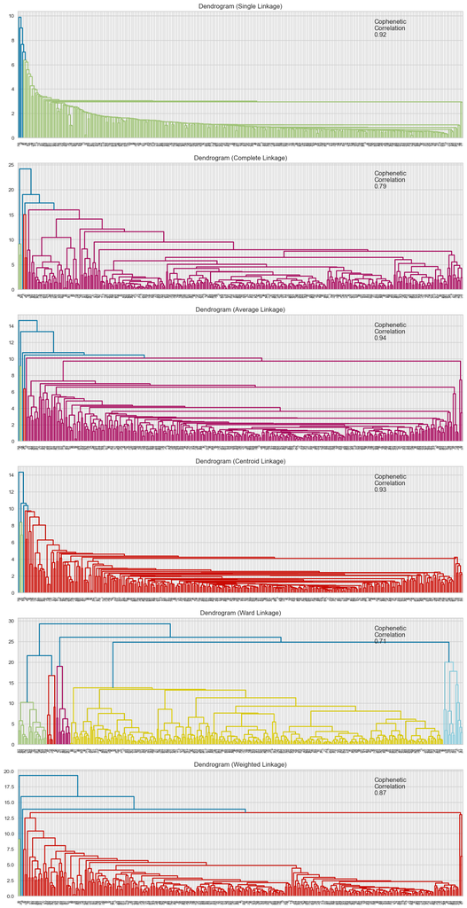

```python
# Linkage methods
linkage_methods = ['single', 'complete', 'average', 'centroid', 'ward', 'weighted']

# Lists to save the results of the cophenetic correlation calculation
compare_cols = ["Linkage", "Cophenetic Coefficient"]
compare = []

# Creating a subplot image
fig, axs = plt.subplots(len(linkage_methods), 1, figsize=(15, 30))

# We will enumerate through the list of linkage methods above
# For each linkage method, we will plot the dendrogram and calculate the cophenetic correlation
for i, method in enumerate(linkage_methods):
    Z = linkage(hc_df, metric="euclidean", method=method)

    dendrogram(Z, ax=axs[i])
    axs[i].set_title(f"Dendrogram ({method.capitalize()} Linkage)")

    coph_corr, coph_dist = cophenet(Z, pdist(hc_df))
    axs[i].annotate(
        f"Cophenetic\nCorrelation\n{coph_corr:0.2f}",
        (0.80, 0.80),
        xycoords="axes fraction",
    )

    compare.append([method, coph_corr])
```

```python
df_cc = pd.DataFrame(compare, columns=compare_cols)
df_cc = df_cc.sort_values(by="Cophenetic Coefficient")
df_cc
```

|  | Linkage | Cophenetic Coefficient |
| --- | --- | --- |
| 4 | ward | 0.710118 |
| 1 | complete | 0.787328 |
| 5 | weighted | 0.869378 |
| 0 | single | 0.923227 |
| 3 | centroid | 0.931401 |
| 2 | average | 0.942254 |

## Creating model using sklearn

```python
%%time

HCmodel = AgglomerativeClustering(n_clusters=4, metric='euclidean', linkage='average')
HCmodel.fit(hc_df)
```

```
CPU times: total: 0 ns
Wall time: 4.5 ms
```

```
AgglomerativeClustering(linkage='average', n_clusters=4)
```

```python
# Copy of the original data
df2 = df.copy()

# Adding hierarchical cluster labels to the original and scaled dataframes
hc_df["HC_segments"] = HCmodel.labels_
df2["HC_segments"] = HCmodel.labels_
```

### Cluster Profiling

```python
hc_cluster_profile = df2.groupby("HC_segments").mean(numeric_only=True)
```

```python
hc_cluster_profile["count_in_each_segment"] = (
    df2.groupby("HC_segments")["Security"].count().values
)
```

```python
hc_cluster_profile.style.highlight_max(color="lightgreen", axis=0)
```

| HC_segments | Current Price | Price Change | Volatility | ROE | Cash Ratio | Net Cash Flow | Net Income | Earnings Per Share | Estimated Shares Outstanding | P/E Ratio | P/B Ratio | count_in_each_segment |
| --- | --- | --- | --- | --- | --- | --- | --- | --- | --- | --- | --- | --- |
| 0 | 77.573266 | 4.148438 | 1.515708 | 35.184524 | 67.154762 | 67104693.452381 | 1607391086.309524 | 2.905640 | 572317821.413095 | 32.325679 | -1.762402 | 336 |
| 1 | 1274.949951 | 3.190527 | 1.268340 | 29.000000 | 184.000000 | -1671386000.000000 | 2551360000.000000 | 50.090000 | 50935516.070000 | 25.453183 | -1.052429 | 1 |
| 2 | 24.485001 | -13.351992 | 3.482611 | 802.000000 | 51.000000 | -1292500000.000000 | -19106500000.000000 | -41.815000 | 519573983.250000 | 60.748608 | 1.565141 | 2 |
| 3 | 104.660004 | 16.224320 | 1.320606 | 8.000000 | 958.000000 | 592000000.000000 | 3669000000.000000 | 1.310000 | 2800763359.000000 | 79.893133 | 5.884467 | 1 |

```python
for cl in df2["HC_segments"].unique():
    print("In cluster {}, the following companies are present:".format(cl))
    print(df2[df2["HC_segments"] == cl]["Security"].unique())
    print()
```

```
In cluster 0, the following companies are present:
['American Airlines Group' 'AbbVie' 'Abbott Laboratories'
 'Adobe Systems Inc' 'Analog Devices, Inc.' 'Archer-Daniels-Midland Co'
 'Alliance Data Systems' 'Ameren Corp' 'American Electric Power'
 'AFLAC Inc' 'American International Group, Inc.'
 'Apartment Investment & Mgmt' 'Assurant Inc' 'Arthur J. Gallagher & Co.'
 'Akamai Technologies Inc' 'Albemarle Corp' 'Alaska Air Group Inc'
 'Allstate Corp' 'Allegion' 'Alexion Pharmaceuticals'
 'Applied Materials Inc' 'AMETEK Inc' 'Affiliated Managers Group Inc'
 'Amgen Inc' 'Ameriprise Financial' 'American Tower Corp A'
 'Amazon.com Inc' 'AutoNation Inc' 'Anthem Inc.' 'Aon plc'
 'Anadarko Petroleum Corp' 'Amphenol Corp' 'Arconic Inc'
 'Activision Blizzard' 'AvalonBay Communities, Inc.' 'Broadcom'
 'American Water Works Company Inc' 'American Express Co' 'Boeing Company'
 'Bank of America Corp' 'Baxter International Inc.' 'BB&T Corporation'
 'Bard (C.R.) Inc.' 'Baker Hughes Inc' 'BIOGEN IDEC Inc.'
 'The Bank of New York Mellon Corp.' 'Ball Corp' 'Bristol-Myers Squibb'
 'Boston Scientific' 'BorgWarner' 'Boston Properties' 'Citigroup Inc.'
 'Caterpillar Inc.' 'Chubb Limited' 'CBRE Group'
 'Crown Castle International Corp.' 'Carnival Corp.' 'Celgene Corp.'
 'CF Industries Holdings Inc' 'Citizens Financial Group' 'Church & Dwight'
 'C. H. Robinson Worldwide' 'Charter Communications' 'CIGNA Corp.'
 'Cincinnati Financial' 'Colgate-Palmolive' 'Comerica Inc.'
 'CME Group Inc.' 'Chipotle Mexican Grill' 'Cummins Inc.' 'CMS Energy'
 'Centene Corporation' 'CenterPoint Energy' 'Capital One Financial'
 'Cabot Oil & Gas' 'The Cooper Companies' 'CSX Corp.' 'CenturyLink Inc'
 'Cognizant Technology Solutions' 'Citrix Systems' 'CVS Health'
 'Chevron Corp.' 'Concho Resources' 'Dominion Resources' 'Delta Air Lines'
 'Du Pont (E.I.)' 'Deere & Co.' 'Discover Financial Services'
 'Quest Diagnostics' 'Danaher Corp.' 'The Walt Disney Company'
 'Discovery Communications-A' 'Discovery Communications-C'
 'Delphi Automotive' 'Digital Realty Trust' 'Dun & Bradstreet'
 'Dover Corp.' 'Dr Pepper Snapple Group' 'Duke Energy' 'DaVita Inc.'
 'Devon Energy Corp.' 'eBay Inc.' 'Ecolab Inc.' 'Consolidated Edison'
 'Equifax Inc.' "Edison Int'l" 'Eastman Chemical' 'EOG Resources'
 'Equinix' 'Equity Residential' 'EQT Corporation' 'Eversource Energy'
 'Essex Property Trust, Inc.' 'E*Trade' 'Eaton Corporation'
 'Entergy Corp.' 'Edwards Lifesciences' 'Exelon Corp.' "Expeditors Int'l"
 'Expedia Inc.' 'Extra Space Storage' 'Ford Motor' 'Fastenal Co'
 'Fortune Brands Home & Security' 'Freeport-McMoran Cp & Gld'
```

[output cut: 61 more lines]

```
 'Wec Energy Group Inc' 'Wells Fargo' 'Whirlpool Corp.'
 'Waste Management Inc.' 'Williams Cos.' 'Western Union Co'
 'Weyerhaeuser Corp.' 'Wyndham Worldwide' 'Wynn Resorts Ltd'
 'Cimarex Energy' 'Xcel Energy Inc' 'XL Capital' 'Exxon Mobil Corp.'
 'Dentsply Sirona' 'Xerox Corp.' 'Xylem Inc.' 'Yahoo Inc.'
 'Yum! Brands Inc' 'Zimmer Biomet Holdings' 'Zions Bancorp' 'Zoetis']

In cluster 2, the following companies are present:
['Apache Corporation' 'Chesapeake Energy']

In cluster 3, the following companies are present:
['Facebook']

In cluster 1, the following companies are present:
['Priceline.com Inc']
```

```python
df2.groupby(["HC_segments", "GICS Sector"])['Security'].count()
```

```
HC_segments  GICS Sector
0            Consumer Discretionary         39
             Consumer Staples               19
             Energy                         28
             Financials                     49
             Health Care                    40
             Industrials                    53
             Information Technology         32
             Materials                      20
             Real Estate                    27
             Telecommunications Services     5
             Utilities                      24
1            Consumer Discretionary          1
2            Energy                          2
3            Information Technology          1
Name: Security, dtype: int64
```

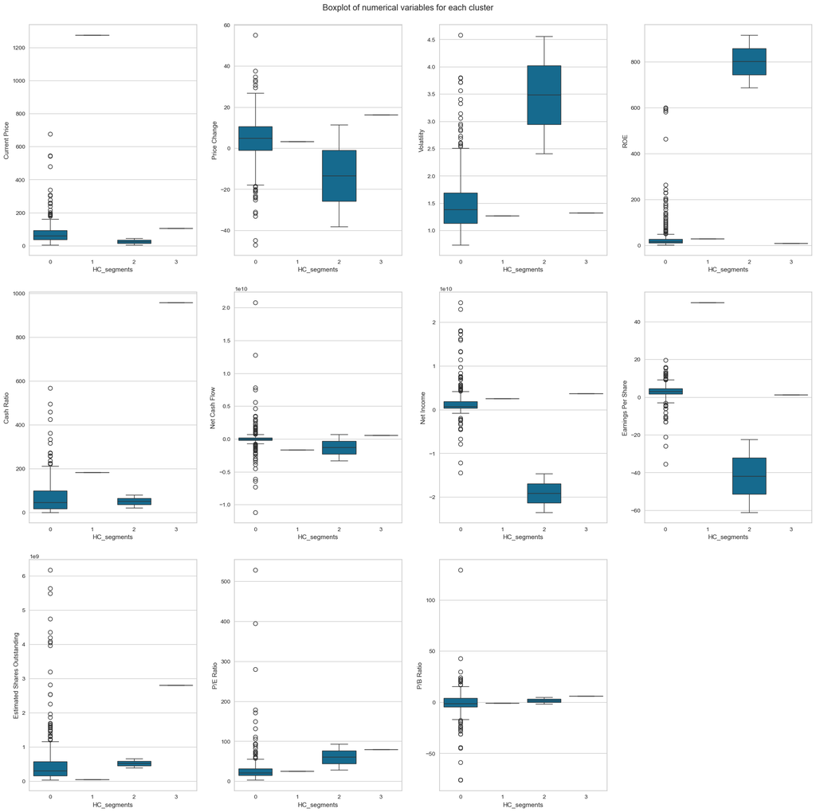

```python
plt.figure(figsize=(20, 20))
plt.suptitle("Boxplot of numerical variables for each cluster")

for i, variable in enumerate(num_col):
    plt.subplot(3, 4, i + 1)
    sns.boxplot(data=df2, x="HC_segments", y=variable)

plt.tight_layout(pad=2.0)
```

### Insights

**Cluster 0**

- Current Price: Moderate (~77.6)
- Price Change: Positive (~4.15)
- Volatility: Moderate (1.52)
- ROE: Moderate (35.2%)
- Cash Ratio: Healthy (67.15)
- Net Cash Flow: Positive (67M)
- Net Income: Very high (~1.6B)
- EPS: Positive (2.91)
- P/E Ratio: Reasonable (32.33)
- P/B Ratio: Negative (-1.76) ← possibly a data artifact
- Count: 336
- **Final Insight:** A large cluster of financially strong, stable companies with good profitability and cash reserves. Excellent for long-term investment with low-to-moderate risk.

**Cluster 1**

- Current Price: Extremely high (~1274.95)
- Price Change: Positive (~3.19)
- Volatility: Low (1.27)
- ROE: Solid (29%)
- Cash Ratio: Very high (184)
- Net Cash Flow: Negative (~-1.67B)
- Net Income: Very high (~2.55B)
- EPS: Very high (50.09)
- P/E Ratio: Reasonable (25.45)
- P/B Ratio: Negative (-1.05) ← possible anomaly
- Count: 1
- **Final Insight:** This is likely an outlier. A high-performing company with huge earnings and stock price, but negative cash flow. Investigate further before considering for portfolio inclusion.

**Cluster 2**

- Current Price: Very low (~24.49)
- Price Change: Most negative (~-13.35)
- Volatility: Highest (3.48)
- ROE: Extremely high (802%) - likely a distortion due to small equity
- Cash Ratio: Fair (51)
- Net Cash Flow: Heavily negative (-1.29B)
- Net Income: Extremely negative (-19.1B)
- EPS: Extremely negative (-41.82)
- P/E Ratio: High (60.75)
- P/B Ratio: Positive (1.57)
- Count: 2
- **Final Insight:** These are severely distressed or failing companies, possibly with accounting or data anomalies. Avoid investing without thorough due diligence.

**Cluster 3**

- Current Price: High (~104.66)
- Price Change: Most positive (~16.22)
- Volatility: Low (1.32)
- ROE: Low (8%)
- Cash Ratio: Very high (958) - likely a cash-rich company
- Net Cash Flow: Strongly positive (~592M)
- Net Income: Very high (~3.67B)
- EPS: Positive (1.31)
- P/E Ratio: Very high (79.89)
- P/B Ratio: High (5.88)
- Count: 1
- **Final Insight:** Another outlier, possibly a high-growth, cash-rich company with strong momentum. Expensive valuation (high P/E & P/B), but may still be attractive to aggressive investors.

## K-means vs Hierarchical Clustering

You compare several things, like:

- Which clustering technique took less time for execution?
- Which clustering technique gave you more distinct clusters, or are they the same?
- How many observations are there in the similar clusters of both algorithms?
- How many clusters are obtained as the appropriate number of clusters from both algorithms?

You can also mention any differences or similarities you obtained in the cluster profiles from both the clustering techniques.

**Number of Clusters**

- Both models were configured to produce 4 clusters.
- This allows for a fair comparison between the two.

**Cluster Sizes**

K-Means:

- Cluster 0: 295
- Cluster 1: 32
- Cluster 2: 2
- Cluster 3: 11

Hierarchical Clustering:

- Cluster 0: 336
- Cluster 1: 1
- Cluster 2: 2
- Cluster 3: 1
- K-Means is more balanced, while Hierarchical isolates extreme values into single-point clusters.

**Cluster Distinctiveness**

Hierarchical clusters are more sharply defined, but:

- Two of them have just 1 observation.
- This can be useful for spotting outliers.
- K-Means clusters are more balanced and interpretable for segmentation.

**Overlap & Similarity**

- Cluster 0 in both = large, stable companies with strong financials.

**Model Behavior**

K-Means:

- Works best with spherical, evenly spread data.
- Requires predefined k.
- Good for scalable, interpretable clustering.

Hierarchical (Agglomerative):

- Automatically builds a dendrogram tree.
- Captures rare, extreme patterns more explicitly.
- Slower on large datasets, but not here (due to smaller size).

## Actionable Insights and Recommendations

### Cluster-Based Strategy

**Cluster 0 (in both models):**

- Large group of financially strong, stable companies.
- Positive net income, positive cash flow, low volatility.
- **Action:** Treat as your core investment segment as they are ideal for long-term, risk-averse investors.

- High price momentum, strong EPS, strong net income.
- Moderate-to-low volatility, positive investor sentiment.
- **Action:** Great for growth-oriented portfolios or tactical high-return plays.

- These are extremely small clusters with outlier behavior.
- Negative income, extreme volatility, or data anomalies.
- **Action:** Treat as data outliers or high-risk bets and investigate before acting.

### Strategic Recommendations

- Use K-Means for balanced segmentation when clusters need to be evenly sized and interpretable for business use.
- Use Hierarchical Clustering for anomaly detection or deeper structural analysis or rare company behavior.
- Align clusters with investor profiles:
  - Conservative: Cluster 0
  - Aggressive growth: Cluster 3
  - Speculative: Cluster 1 & 2
- Integrate cluster logic into portfolio construction tools or dashboards to support analyst decision-making.